# COVID Report

Kevin Park

2026-10-01

Libraries used: tidyverse, ggplot2, lubridate, readr, zoo

## Question of Interest

In this project, I want to explore the mortality rate of COVID19 and particularly compare the mortality rate between countries. Given the presence of a US specific dataset and global dataset, I want to know was there a difference in mortality rate trends over time between the US and the rest of the world? I also would like to explore other avenues where mortality rate can be compared across countries.

## Data Description

The data comes from the COVID19 dataset form the Johns Hopkins Github site. It is composed of four different data sets - two specific to the US and two that contain global information. They contain both the number of daily cases specific to the state/region as well as the number of daily deaths along with other geographical features.

## Data Import

The first step in the project is to import the data. This step is a reproduction of what was presented in lecture.

```r
url_in <- "https://raw.githubusercontent.com/CSSEGISandData/COVID-19/master/csse_covid_19_data/csse_covid_19_time_series/"

file_names <- c("time_series_covid19_confirmed_US.csv",
                "time_series_covid19_deaths_US.csv",
                "time_series_covid19_confirmed_global.csv",
                "time_series_covid19_deaths_global.csv")

urls <- str_c(url_in, file_names)

US_cases <- read_csv(urls[1], show_col_types = FALSE)
US_deaths <- read_csv(urls[2], show_col_types = FALSE)
global_cases <- read_csv(urls[3], show_col_types = FALSE)
global_deaths <- read_csv(urls[4], show_col_types = FALSE)
```

```r
global_cases
```

```
## # A tibble: 289 × 1,147
##    `Province/State`  `Country/Region`   Lat   Long `1/22/20` `1/23/20` `1/24/20`
##    <chr>             <chr>            <dbl>  <dbl>     <dbl>     <dbl>     <dbl>
##  1 <NA>              Afghanistan       33.9  67.7          0         0         0
##  2 <NA>              Albania           41.2  20.2          0         0         0
##  3 <NA>              Algeria           28.0   1.66         0         0         0
##  4 <NA>              Andorra           42.5   1.52         0         0         0
##  5 <NA>              Angola           -11.2  17.9          0         0         0
##  6 <NA>              Antarctica       -71.9  23.3          0         0         0
##  7 <NA>              Antigua and Bar…  17.1 -61.8          0         0         0
##  8 <NA>              Argentina        -38.4 -63.6          0         0         0
##  9 <NA>              Armenia           40.1  45.0          0         0         0
## 10 Australian Capit… Australia        -35.5 149.           0         0         0
## # ℹ 279 more rows
## # ℹ 1,140 more variables: `1/25/20` <dbl>, `1/26/20` <dbl>, `1/27/20` <dbl>,
## #   `1/28/20` <dbl>, `1/29/20` <dbl>, `1/30/20` <dbl>, `1/31/20` <dbl>,
## #   `2/1/20` <dbl>, `2/2/20` <dbl>, `2/3/20` <dbl>, `2/4/20` <dbl>,
## #   `2/5/20` <dbl>, `2/6/20` <dbl>, `2/7/20` <dbl>, `2/8/20` <dbl>,
## #   `2/9/20` <dbl>, `2/10/20` <dbl>, `2/11/20` <dbl>, `2/12/20` <dbl>,
## #   `2/13/20` <dbl>, `2/14/20` <dbl>, `2/15/20` <dbl>, `2/16/20` <dbl>, …
```

## Data Tidying & Transforming

After importing the data and verifying that the tables have loaded successfully, the next step is to tidy the data and verify that the data is plausible. We also transform the data into a clean, easy-to-use format for further analysis and visualization. Again, these steps are repeated from the lecture.

```r
global_deaths <- global_deaths %>%
  pivot_longer(cols = -c('Province/State',
                         'Country/Region',
                         Lat, Long),
               names_to = "date",
               values_to = "deaths") %>%
  select(-c(Lat, Long))

global_cases <- global_cases %>%
  pivot_longer(cols = -c('Province/State',
                         'Country/Region',
                         Lat, Long),
               names_to = "date",
               values_to = "cases") %>%
  select(-c(Lat, Long))

global <- global_cases %>%
  full_join(global_deaths) %>%
  rename(Country_Region = 'Country/Region',
         Province_State = 'Province/State') %>%
  mutate(date=mdy(date))
global
```

```
## # A tibble: 330,327 × 5
##    Province_State Country_Region date       cases deaths
##    <chr>          <chr>          <date>     <dbl>  <dbl>
##  1 <NA>           Afghanistan    2020-01-22     0      0
##  2 <NA>           Afghanistan    2020-01-23     0      0
##  3 <NA>           Afghanistan    2020-01-24     0      0
##  4 <NA>           Afghanistan    2020-01-25     0      0
##  5 <NA>           Afghanistan    2020-01-26     0      0
##  6 <NA>           Afghanistan    2020-01-27     0      0
##  7 <NA>           Afghanistan    2020-01-28     0      0
##  8 <NA>           Afghanistan    2020-01-29     0      0
##  9 <NA>           Afghanistan    2020-01-30     0      0
## 10 <NA>           Afghanistan    2020-01-31     0      0
## # ℹ 330,317 more rows
```

```r
summary(global)
```

```
##    Province_State     Country_Region        date                cases
##  Length   :330327   Length   :330327   Min.   :2020-01-22   Min.   :        0
##  N.unique :    91   N.unique :   201   1st Qu.:2020-11-02   1st Qu.:      680
##  N.blank  :     0   N.blank  :     0   Median :2021-08-15   Median :    14429
##  Min.nchar:     4   Min.nchar:     2   Mean   :2021-08-15   Mean   :   959384
##  Max.nchar:    44   Max.nchar:    32   3rd Qu.:2022-05-28   3rd Qu.:   228517
##  NAs      :226314                      Max.   :2023-03-09   Max.   :103802702
##      deaths
##  Min.   :      0
##  1st Qu.:      3
##  Median :    150
##  Mean   :  13380
##  3rd Qu.:   3032
##  Max.   :1123836
```

```r
global %>% filter(cases > 28000000)
```

```
## # A tibble: 2,510 × 5
##    Province_State Country_Region date          cases deaths
##    <chr>          <chr>          <date>        <dbl>  <dbl>
##  1 <NA>           Brazil         2022-02-18 28072238 643340
##  2 <NA>           Brazil         2022-02-19 28177367 644195
##  3 <NA>           Brazil         2022-02-20 28218180 644592
##  4 <NA>           Brazil         2022-02-21 28258458 644918
##  5 <NA>           Brazil         2022-02-22 28361951 645735
##  6 <NA>           Brazil         2022-02-23 28493336 646714
##  7 <NA>           Brazil         2022-02-24 28589235 647703
##  8 <NA>           Brazil         2022-02-25 28679671 648496
##  9 <NA>           Brazil         2022-02-26 28749552 649184
## 10 <NA>           Brazil         2022-02-27 28776794 649437
## # ℹ 2,500 more rows
```

```r
US_cases <- US_cases %>%
  pivot_longer(cols = -c(UID:Combined_Key),
               names_to =  "date",
               values_to = "cases") %>%
  select(Admin2:cases) %>%
  mutate(date=mdy(date)) %>%
  select(-c(Lat, Long_))

US_deaths <- US_deaths %>%
  pivot_longer(cols = -(UID:Population),
               names_to = "date",
               values_to = "deaths") %>%
  select(Admin2:deaths) %>%
  mutate(date=mdy(date)) %>%
  select(-c(Lat, Long_))

US <- US_cases %>%
  full_join(US_deaths)
```

[output not shown]

```r
US
```

```
## # A tibble: 3,819,906 × 8
##    Admin2 Province_State Country_Region Combined_Key date       cases Population
##    <chr>  <chr>          <chr>          <chr>        <date>     <dbl>      <dbl>
##  1 Autau… Alabama        US             Autauga, Al… 2020-01-22     0      55869
##  2 Autau… Alabama        US             Autauga, Al… 2020-01-23     0      55869
##  3 Autau… Alabama        US             Autauga, Al… 2020-01-24     0      55869
##  4 Autau… Alabama        US             Autauga, Al… 2020-01-25     0      55869
##  5 Autau… Alabama        US             Autauga, Al… 2020-01-26     0      55869
##  6 Autau… Alabama        US             Autauga, Al… 2020-01-27     0      55869
##  7 Autau… Alabama        US             Autauga, Al… 2020-01-28     0      55869
##  8 Autau… Alabama        US             Autauga, Al… 2020-01-29     0      55869
##  9 Autau… Alabama        US             Autauga, Al… 2020-01-30     0      55869
## 10 Autau… Alabama        US             Autauga, Al… 2020-01-31     0      55869
## # ℹ 3,819,896 more rows
## # ℹ 1 more variable: deaths <dbl>
```

```r
summary(US)
```

```
##        Admin2          Province_State      Country_Region
##  Length   :3819906   Length   :3819906   Length   :3819906
##  N.unique :   1980   N.unique :     58   N.unique :      1
##  N.blank  :      0   N.blank  :      0   N.blank  :      0
##  Min.nchar:      3   Min.nchar:      4   Min.nchar:      2
##  Max.nchar:     41   Max.nchar:     24   Max.nchar:      2
##  NAs      :   6858
##     Combined_Key          date                cases           Population
##  Length   :3819906   Min.   :2020-01-22   Min.   :  -3073   Min.   :       0
##  N.unique :   3342   1st Qu.:2020-11-02   1st Qu.:    330   1st Qu.:    9917
##  N.blank  :      0   Median :2021-08-15   Median :   2272   Median :   24892
##  Min.nchar:      8   Mean   :2021-08-15   Mean   :  14088   Mean   :   99604
##  Max.nchar:     55   3rd Qu.:2022-05-28   3rd Qu.:   8159   3rd Qu.:   64979
##                      Max.   :2023-03-09   Max.   :3710586   Max.   :10039107
##      deaths
##  Min.   :  -82.0
##  1st Qu.:    4.0
##  Median :   37.0
##  Mean   :  186.9
##  3rd Qu.:  122.0
##  Max.   :35545.0
```

## Data Visualizations and Analyses

### Visualization + Analysis 1

For the first visualization of the project, I want to take a look at the mortality rates over time and analyze the results for the global data vs. the US data. The goal is to try to determine any noticeable differences and similarities between the two datasets and draw meaningful insights from them.

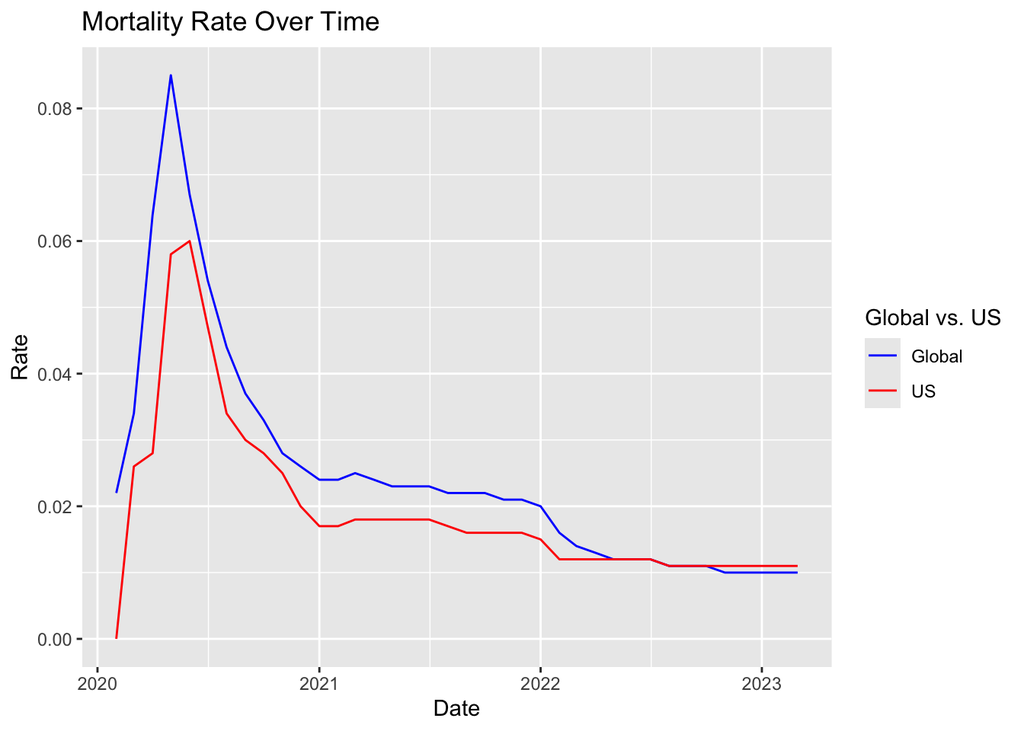

```r
daily_mortality_rate_global <- global %>%
  filter(cases > 0, Country_Region != "US") %>%
  group_by(date) %>%
  summarize(
    daily_cases = sum(cases),
    daily_deaths = sum(deaths),
  ) %>%
  mutate(
    mortality_rate = round(daily_deaths/daily_cases, 3)
  )

monthly_plot = daily_mortality_rate_global %>%
  filter(day(date) == 1)

daily_mortality_rate_US <- US %>%
  filter(cases > 0) %>%
  group_by(date) %>%
  summarize(
    daily_cases = sum(cases),
    daily_deaths = sum(deaths),
  ) %>%
  mutate(
    mortality_rate = round(daily_deaths/daily_cases, 3)
  )

monthly_plot_US <- daily_mortality_rate_US %>%
  filter(day(date) == 1)

ggplot() +
  geom_line(data = monthly_plot,
            aes(x = date, y = mortality_rate, color = "Source 1")
            ) +
  geom_line(data = monthly_plot_US,
            aes(x = date, y = mortality_rate, color="Source 2")
            ) +
  labs(x = "Date",
       y = "Mortality Rate"
  ) +
  scale_color_manual(
    name = "Global vs. US",
    values = c("Source 1" = "blue",
               "Source 2" = "red"
               ),
    labels = c("Source 1" = "Global",
               "Source 2" = "US")
  ) +
  labs(title = "Mortality Rate Over Time", y="Rate", x = "Date")
```

Note: I chose to only plot the rolling values as of the first of the month, as the marginal changes in counts and deaths compared to the large overall numbers caused the rate to update only periodically. This daily view caused a step-like view on the visualization and thus I shifted to a monthly visualization to smooth out the plot. I also removed US from the global dataset to do a pure comparison of global vs US values.

As we can see in the visualization, the US follows the global trend fairly closely with the mortality rate spiking in mid-2020 then tapering off and slowly declining over time. A plausible explanation would be that the US was no exception towards the global exposure to COVID and was susceptible to the same outcomes as the rest of the world. We can also see that the overall mortality rate was lower in general for the US vs. globally. This could be caused by several potential phenomena. One potential reason could be that the US may have more advanced medical technology than the global average, thus being more apt in reducing the mortality rate. Another potential reason could be the method reporting cases/deaths. Perhaps the US had more avenues to report a positive COVID test, regardless of severity whereas other counties around the globe may only report serious cases, which have a higher likelihood of death. These potential explanations would require further investigation out of the context of this course to ensure that these assumptions are justified and are ethically sound.

### Visualization + Analysis 2

For the second visualization, I wanted to identify the countries with the highest peak mortality rates recorded. For the sake of achieving a sufficient sample size, I only accounted for rates once the number of cases reached at least 100.

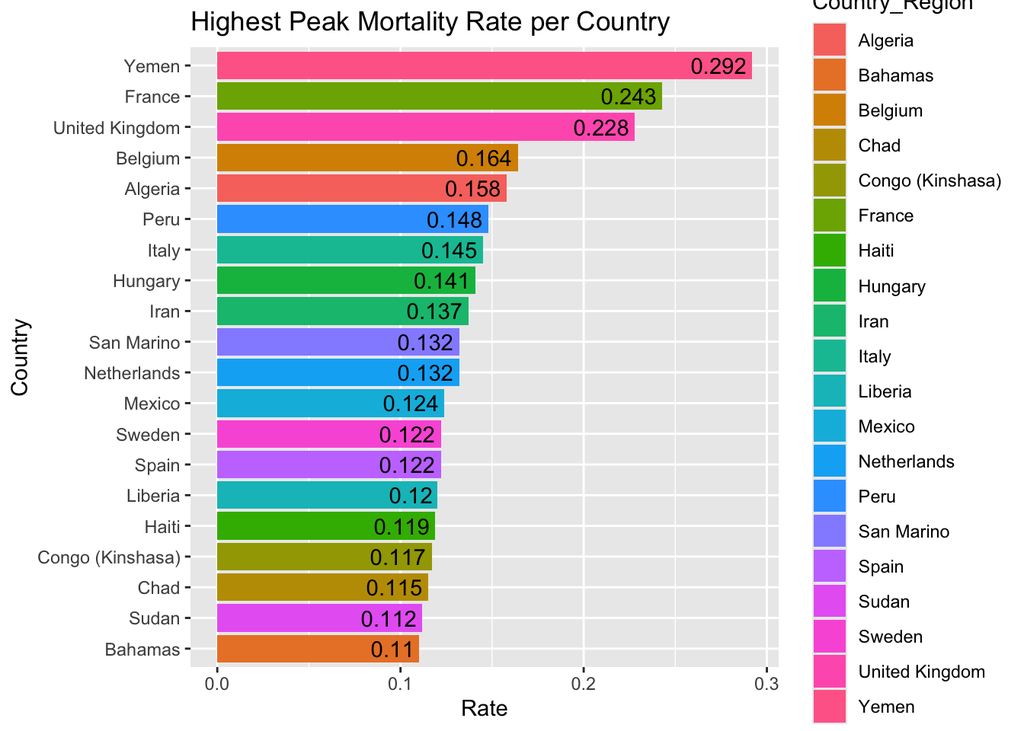

```r
global_rate <- global %>%
  filter(cases >= 100) %>%
  mutate(mortality_rate = round(deaths/cases, 3))

country_max <- global_rate %>%
  group_by(Country_Region) %>%
  summarize(mortality_rate = max(mortality_rate)) %>%
  arrange(desc(mortality_rate))

ggplot(
  data = country_max %>% slice_head(n=20),
  aes(x = reorder(Country_Region, mortality_rate), y=mortality_rate, fill=Country_Region)
) +
  geom_col() +
  geom_text(
    aes(label=mortality_rate),
    hjust = 1.1
  ) +
  labs(title = "Highest Peak Mortality Rate per Country", y="Rate", x = "Country") +
  coord_flip()
```

From this plot, we can see the top 20 countries that reached the highest mortality rates having at least 100 confirmed COVID cases. We can see that Europe has the most countries appearing in the top 20, having 9 countries that appear. We can see a steep drop off from the top 3 countries (Yemen, France, United Kingdom) from the rest, with the top 3 reaching peak mortality rates of above 20%. Several considerations should be made when interpreting this data. Differing reporting methods, healthcare capabilities, and affects relative to the population could all affect this data and influence the reporting of these numbers. While we can draw conclusions of how countries were impacted by COVID relative to each other on this scale, further analysis should be done to truly understand how these countries were affected compared to each other.

## Data Modeling

```r
country_daily <- global %>%
  filter(cases >= 100, deaths >= 0, Country_Region != "US") %>%
  group_by(Country_Region, date) %>%
  summarize(
    daily_cases = sum(cases),
    daily_deaths = sum(deaths),
  ) %>%
  mutate(
    mortality_rate = round(daily_deaths/daily_cases, 3)
  )
```

```
## `summarise()` has regrouped the output.
## ℹ Summaries were computed grouped by Country_Region and date.
## ℹ Output is grouped by Country_Region.
## ℹ Use `summarise(.groups = "drop_last")` to silence this message.
## ℹ Use `summarise(.by = c(Country_Region, date))` for per-operation grouping
##   (`?dplyr::dplyr_by`) instead.
```

```r
country_monthly <- country_daily %>%
  filter(day(date) == 1, mortality_rate < 1)

country_matrix <- country_monthly %>%
  select(Country_Region, date, mortality_rate) %>%
  pivot_wider(
    names_from = date,
    values_from = mortality_rate
  ) %>%
  #Imputation to handle Nulls for KMeans Modeling
  rowwise() %>%
  mutate(
    country_mean = mean(c_across(where(is.numeric)), na.rm=TRUE),
    across(where(is.numeric), ~ifelse(is.na(.x), country_mean, .x)
  )
  ) %>%
  ungroup () %>%
  select(-country_mean)


X <- country_matrix %>%
  select(-Country_Region) %>%
  as.matrix()

X_scale = scale(X)
```

```r
km <- kmeans(X_scale, centers = 5, nstart = 25)
country_groups <- country_matrix %>%
  select(Country_Region) %>%
  mutate(cluster = factor(km$cluster))
```

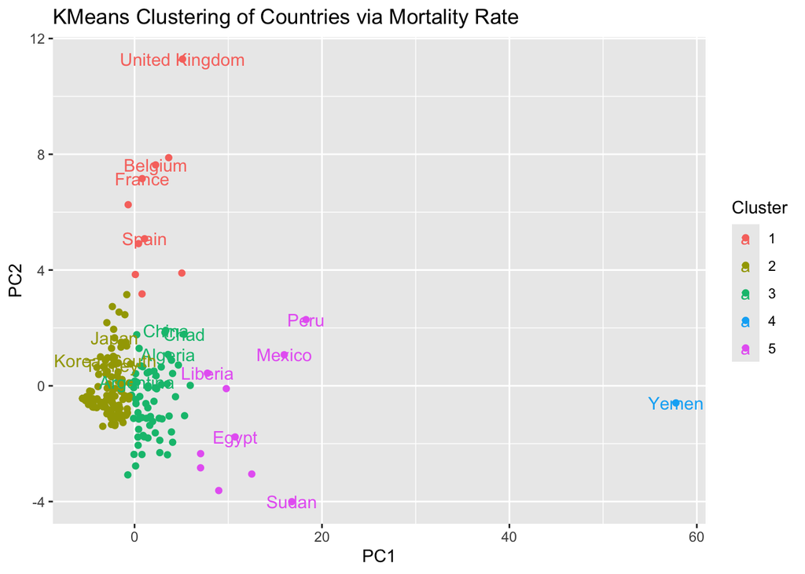

```r
pca <- prcomp(X_scale)
clustering_df <- data.frame(
  Country_Region = country_matrix$Country_Region[complete.cases(country_matrix %>% select(-Country_Region))],
  PC1 = pca$x[,1],
  PC2 = pca$x[,2],
  Cluster = factor(km$cluster)
)

ggplot(clustering_df, aes(x=PC1, y=PC2, color = Cluster)) +
  geom_point() +
  geom_text(aes(label = ifelse(
    Country_Region %in% c("Yemen", "United Kingdom", "France", "Spain", "Belgium", "Algeria", "Liberia", "Peru", "Mexico", "Korea, South", "China", "Japan", "Turkey", "Sudan", "Chad", "Egypt", "Argentina"), Country_Region, ""
  ))) +
  labs(title = "KMeans Clustering of Countries via Mortality Rate")
```

## Bias Evaluation + Conclusion

There are many possibilities for analysis and discovery regarding the COVID dataset. In my analysis, I focused on exploring mortality rate and the comparisons between countries. I was able to uncover some similarity when comparing the US and global mortality rates over time and was able to cluster countries based off of how similar their mortality rates trended over time. Mortality rate is just one avenue to pursue with this data, and I am eager to explore further and draw more insights. However, with this analysis must come a conscious effort to mitigate bias. I made assumptions about the capabilities of several countries’ healthcare and reporting in my report and in doing so I may have introduced bias that I quickly noted must be explored and investigated to ensure that these assumptions are justified and ethical. My country selection when plotting the KMeans model has implicit bias, as they were chosen at my discretion. Also within the KMeans model, due to imputations, the results may have been biased involving countries with more/less reporting. When plotting the countries with the top mortality rates, it is important that it is noted that the plot is not a conclusive view of any attribute of any country, and rather and conclusion should be done with further research and context. I did my best to only visualize what the data provided, but any further conclusion, cannot be made via this report.